# Evaluación bioeconómica del plan de recuperación de la pesquería del callo de hacha (*Atrina maura, Atrina tuberculosa & Pinna rugosa*) de la bahía de La Paz (BCS) México

Juliano Palacios Abrantes, Juliana Herrera Correal, Salvador Rodríguez, Jacy Brunkow y Renato Molina

04/2019

- **NOTA: esta es una traducción al español del artículo** *Evaluating the bio-economic performance of a Callo de hacha (Atrina maura, Atrina tuberculosa & Pinna rugosa) fishery restoration plan in La Paz, Mexico.* escrito por Juliano Palacios Abrantes, Juliana Herrera, Salvador Rodríguez, Jacy Brunkow y Renato Molina y que se puede encontrar en el siguiente [link](https://doi.org/10.1371/journal.pone.0209431).
- **Palacios-Abrantes J**, Herrera-Correal J, Rodríguez S, Brunkow J, Molina R (2018) Evaluating the bio-economic performance of a Callo de hacha (*Atrina maura, Atrina tuberculosa & Pinna rugosa*) fishery restoration plan in La Paz, Mexico. *PLoS ONE* 13(12): e0209431. DOI: doi.org/10.1371/journal.pone.0209431

Descargar traducción en PDF

# Resúmen

Las pesquerías de pequeña escala contrinuyen de manera importante a la economía y bienestar de las comunidades costeras de América Latina. Si bien México es uno de los casos en que la pesca de pequeña escala desempeña un papel importante, la sobrepesca y estrategias de gestión pesquera ineficientes han llevado al colapso de muchas de sus pesquerías. La pesquería de callo de hacha de la Ensenada de La Paz en Baja California Sur es un ejemplo de una pesquería que, después de años de mala gestión, fue cerrada por las autoridades mexicanas en 2009. El presente estudio evaluó los esfuerzos de recuperación en la ensenada y los posibles resultados de una colaboración entre una organización no gubernamental y una comunidad pesquera que trabaja para la restauración de esta pesquería de concha. Después de más de cuatro años de cierre y monitoreo activo del proceso de recuperación, la población de callo de hacha mostró una recuperación significativa de la población, con una posible solvencia para reabrir las actividades pesqueras. Se evaluaron cuatro escenarios de incertidumbre y dos de ellos proporcionan valores presentes netos positivos desde la reapertura de la pesquería. También documentamos la participación de una organización no gubernamental con una comunidad pesquera, que creó capital social y, en nuestra opinión, fue esencial para una restauración exitosa. Tener una comunidad activamente involucrada ayudó a recaudar fondos para el cierre de la pesca para que los pescadores pudieran cumplir con la legislación mexicana, también fomentó la construcción de la comunidad y la autoorganización que serán cruciales para mantener la sostenibilidad de la pesquería.

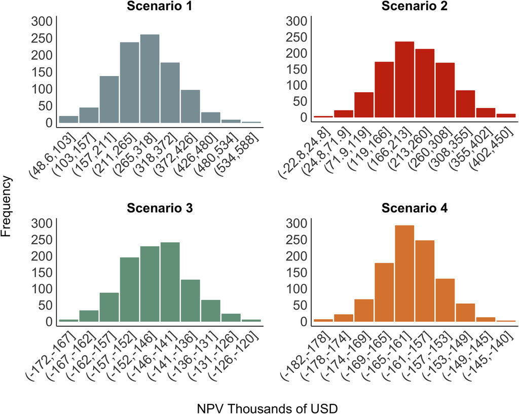

**Simulaciones del valor presente neto para cada escenario de callo de hacha. Se realizaron 1000 simulaciones para cada escenario.** https://doi.org/10.1371/journal.pone.0209431.g002

# Introducción

Las pesquerías artesanales (también conocidas como de menor escala) son importantes para la economía regional y para el bienestar de las comunidades costeras de América Latina [1]. Sin embargo, las propias características de dichas pesquerías significan un gran reto para su manejo [2]. Este es el caso de las pesquerías de México, uno de los mayores productores de pescados y mariscos de América Latina, donde el 97% de los barcos pesqueros son artesanales [2] y donde el manejo inadecuado de recursos pesqueros ha resultado en la sobreexplotación de diversos recursos [3,4]. Algunos ejemplos en la costa del Pacífico incluyen la almeja chocolata (*Megapitaria squalida*) [5] y los abulones azul (*Haliotis fulgens*) y amarillo (*Haliotis corrugata*) [6]; mientras que, en la costa del Atlántico, peces pelágicos como el pez sierra (*Scomberomorus maculatus*) y el pargo rojo (*Lutjanus campechanus*) han sido clasificados como recursos sobreexplotados [3]. La recuperación de pesquerías sobreexplotadas es una prioridad para que las comunidades que dependen de dichos recursos puedan obtener beneficios a través de un manejo pesquero sustentable que asegure el bienestar de futuras generaciones [4,7,8].

Si bien existen varios casos exitosos de recuperación de pesquerías a nivel mundial para distintas especies, como el jurel (*Scomberomorus cavalla*), el bajo puntiagudo (*Marone saxatilis*) y las vieiras (*Placopecten magellanicus*) [21], muy poco ha sido documentado respecto al desempeño de pesquerías mexicanas [3], como al del callo de hacha en La Paz. El presente estudio examina un esfuerzo comunitario para recuperar la pesquería artesanal del callo de hacha de la ensenada de La Paz, Baja California Sur, México. La pesquería del callo de hacha se compone de tres especies: *Atrina maura, Atrina tuberculosa* y *Pinna rugosa* y representa uno de los productos mejor valorados de la pesca artesanal de la región [9]. Con precios históricos de hasta US$\$$ 23.00 por kg en La Paz [10], los pescadores reportaron un precio en abril de 2018 de US$\$$ 21.00 por kg de callo. Dicho precio es 50% más alto que el de otros moluscos del mismo tipo en el mercado de mariscos del país [10].

En México, el manejo pesquero se encuentra bajo la gestión de varios departamentos dentro de la Secretaría de Agricultura, Ganadería, Desarrollo Rural, Pesca y Alimentación (SAGARPA). La principal ley de manejo pesquero es la “Ley General de Pesca y Acuacultura Sustentables (LGPAS)” [11], que establece las obligaciones y pautas para la mayoría de las pesquerías en el país a través de la “Carta Nacional Pesquera” [12]. Por ley, el Instituto Nacional de Pesca (INAPESCA) está encargado de recomendar cuotas de pesca al Consejo Nacional de Pesca (CONAPESCA), quien es responsable de implementar las acciones de manejo necesarias para cumplir con las recomendaciones. Finalmente, la vigilancia y monitoreo de las actividades pesqueras son responsabilidad del CONAPESCA y de la Secretaría de Marina (SEMAR) [11]. A pesar de estos marcos regulatorios, algunas pesquerías como el callo de hacha carecen de un plan de manejo adecuado o de una norma oficial [12], lo que permite que varias pesquerías artesanales operen bajo el régimen de acceso abierto [13,14].

En respuesta a dicha situación, una ONG local, Noroeste Sustentable (NOS), se asoció con la comunidad pesquera del Manglito, de la ensenada de La Paz, para lanzar un plan conjunto de restauración de la pesquería del callo de hacha. La iniciativa buscó aumentar la biomasa hasta alcanzar las cantidades necesarias para reabrir la pesca comercial y, al mismo tiempo, ayudar a la comunidad a obtener derechos de propiedad sobre el callo, así como incentivar una administración sustentable del recurso [17,18]. La obtención de derechos de propiedad sobre el recurso era esencial para la comunidad si ésta quería beneficiarse del plan de restauración y garantizar la pesca sustentable [4]. NOS pudo financiar a los pescadores para que participaran en varias actividades relacionadas con el plan de recuperación, lo que se tradujo en más de cuatro años de monitoreo de la biomasa del callo de hacha en la ensenada. El plan de recuperación fue cuidadoso al considerar no sólo las condiciones biológicas del *stock*, sino también los marcos económicos y legales que rigen a la pesquería, así como la dinámica social de la comunidad pesquera; todos elementos identificados previamente como componentes importantes del proceso de restauración pesquera [16,19-21].

La generación de capital social, es decir, la determinación de reglas dentro de comunidades estrechamente unidas, parece ser fundamental para el desarrollo comunitario de manejo pesquero en América Latina [22]. De esta manera, el programa de recuperación del callo de hacha incorporó con éxito esta noción y se empeñó en la construcción de capital social al involucrarse con la comunidad para desarrollar conjuntamente sus objetivos sociales, económicos y ambientales. El programa estuvo centrado en la promoción de la auto organización y la aplicación de la ley, así como en el lanzamiento de campañas de información que difundían prácticas de pesca sostenible. Los talleres dirigidos por NOS también brindaron un espacio para discutir la organización de la comunidad, solucionar problemas internos y determinar estrategias de manejo y políticas de pesca. Estas actividades les dieron a los pescadores un sentido de propiedad sobre el recurso, les permitieron establecer sus propias reglas internas y promovieron métodos de captura sostenibles. Finalmente, el proceso también ayudó a superar las diferencias dentro de la comunidad y resultó en la formación de un colectivo cooperativo de los pescadores. El colectivo “Organización de Pescadores Rescatando la Ensenada” fue clave para controlar la pesca ilegal, así como para garantizar los derechos de propiedad sobre un recurso que finalmente se recuperó. Esta transición condujo a la pesquería, al menos desde la perspectiva de los pescadores, desde el acceso abierto de facto a un sistema basado en derechos de propiedad [17,18].

El objetivo del presente estudio fue evaluar el desempeño del plan de restauración del callo de hacha en términos de biomasa y su equivalencia económica, un plan que reunía las condiciones para reabrir una pesquería de alto valor. El análisis se basó en datos biológicos colectados desde el cierre de la pesquería, así como una evaluación de las mejores variables económicas disponibles para su operación. Los resultados sugieren que, después de cuatro años (2011-2014), el recurso se recuperó sustancialmente, lo que hace de la pesquería un negocio potencialmente rentable con beneficios significativos para la comunidad. Sin embargo, el grado de incertidumbre de las muestras biológicas dificulta el análisis económico, ya que, si bien la pesquería podría ser rentable, los escenarios más pesimistas son una advertencia contra expectativas altamente positivas al ocultar los verdaderos beneficios de la pesquería del callo de hacha de la ensenada de La Paz.

# Materiales y Métodos

En el presente estudio se utilizó la biomasa del callo de hacha y el valor económico de la pesquería para determinar el éxito del plan de recuperación, por lo que los métodos se dividen en tres segmentos: estimación de biomasa, análisis económico y fuente de datos.

## Estimación de biomasa

La biomasa total del callo de hacha en la ensenada fue estimada a partir de la abundancia promedio considerando la estructura de tallas de la población [23]. Inicialmente se estimó el peso de cada individuo medido (*W*) utilizando una ecuación de crecimiento alométrico [24]:

$$W = a (L^b)$$

donde *a* es una constante, *L* es el tamaño del individuo y *b* es el crecimiento intrínseco de la especie. Los valores de *a* y *b* fueron tomados de Serrano-Guzmán (2004) [24]. Posteriormente se estimó el peso promedio ($\bar{W}$) de acuerdo con la siguiente ecuación [23]:

$$\bar{W} =
\sum^n_{i=1}\frac{X_i}{n_i}$$

donde *$X_i$* es el peso agregado de todos los individuos del cuadrante *i* y *n* es el área muestreada en cada cuadrante. El peso promedio fue utilizado para estimar la biomasa promedio (*B*) multiplicando *$X_i$* por el área total ocupada por el recurso en la ensenada. Así mismo, se estimó la varianza del peso y biomasa promedio con intervalos de confianza (95%) utilizando el método descrito por DeLong et. al. (1988) [25]. La biomasa disponible para pesca (de ahora en adelante referida como, biomasa extraíble) fue estimada utilizando únicamente individuos de más de 14 cm, la talla mínima determinada por la ley mexicana, [12] y se asumió que lo que se vende principalmente es el músculo abductor del callo de hacha, estimado en 25% del peso total del individuo [26].

La limitante principal de este análisis fue la imposibilidad de proyectar la dinámica poblacional debido a restricciones en los datos y el número de observaciones disponibles. Un intento inicial de establecer una relación entre la biomasa reproductora y nuevos reclutas tuvo que ser descartado debido al bajo número de observaciones disponibles (Fig. S1). Además, existe un conocimiento biológico limitado de la población, lo que impidió determinar si ésta era autosuficiente (en términos de crecimiento poblacional) o si las larvas de nuevos reclutas provenían de fuentes externas.

Para lidiar con dicha limitación, pero aún así proporcionar información sobre la viabilidad económica de la pesquería, se asumió que la población estaba en equilibrio en el último año muestreado debido al bajo grado de variación con respecto al año anterior. Posteriormente se realizaron proyecciones asumiendo que el stock estará en equilibrio y sometido a una mortalidad pesquera fija. Así, para cada año la biomasa extraíble (*H*) se proyectó aleatoriamente de la siguiente manera, a partir de una distribución normal con un componente de ruido:

$$H{(\pi|\mu,\sigma^2)} =
\frac{1}{\sqrt{2\pi\sigma^2}}e^\frac{R-\mu^2}{2\sigma^2}$$

donde $\pi$ es una variable aleatoria con distribución normal, ($\mu$) es la biomasa media en equilibrio de individuos mayores a 14 cm y ($\sigma$) es la desviación estándar. Para todos los años, la mortalidad poblacional por pesca se estableció en 20% de *H*, según lo recomendado por la carta nacional pesquera mexicana [12] y utilizada en otras pesquerías similares [23]. Al incluir un componente aleatorio en la estimación de biomasa, el análisis captura posibles variaciones poblacionales que pudieran influenciar la disponibilidad anual de biomasa extraíble.

## Análisis económico

El modelo económico fue desarrollado para estimar la rentabilidad de la pesquería del callo de hacha, aunque éste se pueda adaptar a otras pesquerías (Archivo S2, *Excel*). El análisis funciona como un simulador de escenarios y considera diferentes pasos a lo largo del proceso de pesca (desde la biomasa extraíble, hasta variables económicas como precio de venta y costos de pesca). Para calcular los beneficios económicos generados por la pesquería, la captura (*C*) se estimó en cada simulación a partir del valor aleatorio de distribución normal previamente descrito de la siguiente manera:

$$C = (H*F) *CF$$

donde *F* es la mortalidad por pesca y *CF* es el factor de conversión del músculo individual. El costo total de la actividad pesquera (*Tc*) se estimó a partir de los costos fijos, que fueron divididos en costos operacionales y específicos de la embarcación, y costos variables, divididos en costo por viaje y por unidad de captura. Esta diferenciación se debe a que la pesquería del callo de hacha tiene costos fijos anuales asociados con la operación de la embarcación y el acceso a la pesquería, y costos variables asociados con el esfuerzo de pesca y el manejo del producto. Por ejemplo, cada pescador debe pagar un permiso anual de pesca y embarcación (costo fijo anual), y para cada embarcación utilizada (unidad de esfuerzo) el pescador debe cubrir el combustible y aceite (costo fijo por viaje). Una vez realizada la operación de pesca, los costos con bolsas de hielo y con combustible utilizados en el traslado del producto (si éste no se vende en playa) dependen de la cantidad de captura (unidad de captura). De esta manera, el costo operacional de la actividad pesquera (*OFC*) se calculó a partir de:

$$OFC = \sum_{j=1}^{n} Yc$$

donde *Yc* es igual a los costos anuales relacionados con la operación de la pesquería, y *j* representa las diferentes fuentes de costo. El índice de tiempo se ha omitido para mayor claridad. El costo fijo de la embarcación (*VFC*) fue estimado a partir de:

$$VFC = (\sum_{j=1}^{n}
Bc)*Bu$$

donde *Bc* representa los costos fijos anuales relacionados únicamente con la disponibilidad de la embarcación y *Bu* representa la fracción relativa de la capacidad total de la embarcación utilizada para pescar callo de hacha. Finalmente, el costo variable (*VC*) se estimó como:

$$VC = - (E *Ce) + (C * Cc)$$

donde *E* es el esfuerzo (número de viajes necesarios para la captura *C*), *Ce* es el costo por unidad de esfuerzo, definido por la suma de los costos por viaje de pesca, y *Cc* es el costo por unidad de captura. El costo total de pesca (*Tc*) es el resultado de la suma de *OFC*, *VFC* y *Vc.*

El ingreso pesquero (*R*) se estimó multiplicando *C* por la proporción del músculo abductor del callo, multiplicado, a su vez, por el precio de venta. El Valor Presente Neto (*NPV*) se descontó y proyectó durante un período de 10 años de la siguiente manera:

$$NPV = \sum_{y=0}^{y=10}\frac{R- (Tc -
Tax)}{(1+r)^y}$$

donde *Tax* son impuestos, *y* representa el año en curso y *r* es la tasa de descuento. Se asumió que la tasa de descuento era del 10%. Se utilizaron tasas de descuento adicionales (5, 10 y 15%) para probar la sensibilidad del modelo a este supuesto.

Finalmente, se llevó a cabo una simulación de estilo *Monte Carlo* con un total de 1000 ejecuciones por escenario. Para cada año de simulación (*n = 10*), el modelo determinó aleatoriamente la biomasa extraíble a partir del promedio de la biomasa en equilibrio (± s.d). Todas las demás variables se mantuvieron constantes a lo largo de las simulaciones.

## Fuentes de datos

El presente estudio se realizó a partir de datos biológicos de *Atrina maura, A. tuberculosa* y *Pinna rugosa*, que constituyen la pesquería del callo de hacha en la Ensenada de La Paz. Los datos fueron recopilados por pescadores locales con el apoyo de NOS, a través de una campaña de monitoreo anual desde 2011 hasta 2014 (datos sin procesar en datos S1). Dado que estas tres especies comparten características biológicas similares, toda la población muestreada fue considerada como un solo stock [27]. Este supuesto es factible ya que el análisis no modela la dinámica poblacional de la especie, y a pesar de que se perdió especificidad, dicho supuesto permitió tener una idea más amplia de la rentabilidad de la pesquería del callo de hacha.

Varias inconsistencias presentes en de los datos sin procesar a lo largo de los años de monitoreo tuvieron que ser consideradas al realizar el análisis. Así, para estimar el tamaño de los individuos que se contaron, pero no se midieron, se utilizó una proporción del peso bruto medido (Ec. 1). Se asumió que la estructura de tallas de la población medida representaba de manera adecuada la estructura general de todo el cuadrante. Por ejemplo, si el 10% de los individuos medidos de un cuadrante tenían 18 cm de longitud y, por lo tanto, cada uno pesaba 100 g, entonces el 10% de los individuos de dicho cuadrante que fueron contados (pero no medidos) tenían la misma longitud y, por consecuencia, el mismo peso. En segundo lugar, cuatro cuadrantes en 2013 y 12 en 2014 presentaron valores de biomasa considerablemente mayores que los demás cuadrantes, por lo que se asumió que el stock se dividía en dos subpoblaciones; una en los cuadrantes que presentaban densidades altas y otra en los cuadrantes que tenían densidades bajas. Finalmente, el área muestreada fue inconsistente a lo largo de los años debido a los diferentes métodos de muestreo utilizados (ej., transectos de 5x5 m contra transectos de 50x5 m) y al diferente número de cuadrantes muestreados. Por lo tanto, para determinar la biomasa total de la población extrapolamos la población muestreada a todo el cuadrante y a la ensenada, teniendo en cuenta las diferentes áreas muestreadas.

# Resultados

## Resultados económicos

Los resultados de las simulaciones de las distintas muestras biológicas de Monte Carlo sugieren que la pesquería del callo de hacha es una actividad rentable (VPN positivo) en dos de los cuatro escenarios económicos (Fig. 2). Mientras que los escenarios 1 y 2 indican una rentabilidad neta positiva, los escenarios 3 y 4 conducirían a una posible pérdida económica.

# Discusión

La recuperación de la población del callo no es necesariamente sorprendente, ya que es de esperarse que una población biológica se recupere con el tiempo ante una veda de pesca. Dicha recuperación, sin embargo, es una función del grado de efectividad (¿) de la medida para detener la pesca. Lo que hace de este caso un valioso ejemplo para el manejo pesquero es la veda pesquera y la recuperación efectiva del recurso, dentro de un contexto de falta de manejo (oficial) y sin claros derechos de propiedad establecidos. Es probable que dicho resultado sea altamente dependiente de la participación de la comunidad pesquera en el plan de manejo, desde su inicio y a través de todo el proceso.

Es posible que factores biológicos del callo de hacha, así como las características ambientales, también hayan contribuido a las dinámicas de recuperación de la población. Por ejemplo, el callo de hacha es un bivalvo que tiende a agregarse, por lo que la formación de parches con altas concentraciones de individuos favorece el crecimiento poblacional [32]. Esto pudo haber sucedido en la ensenada de La Paz después de 2013, cuando la densidad de la población llegó a tal grado que el reclutamiento fue favorable. Sin embargo, la efectividad de dicho proceso depende de que los pescadores respeten la veda, lo que resalta la importancia de la participación de la comunidad en todo el proceso.

Dada la metodología empleada en el análisis, las fuentes de incertidumbre previamente mencionadas también influencian los escenarios económicos. Según el modelo, si el callo de hacha se cosechara en el momento del presente estudio bajo un manejo adecuado, sólo serían rentables los escenarios 1 y 2 (Fig. 2). Dichos escenarios proporcionarían empleo a 104 (Escenario 1) y 81 (Escenario 2) pescadores con un salario mínimo por temporada de pesca [34]. Sin embargo, es importante tener en cuenta que estas ganancias reflejan una proporción fija entre el músculo abductor (parte comestible) y el individuo, y que las ganancias podrían aumentar si los pescadores retirasen animales con músculos aductores mayores. Asimismo, estrategias de manejo que consideren las características económicas de la pesquería se beneficiarían de tener en cuenta dicho supuesto.

Los resultados para los escenarios 3 y 4, que no consideran los cuadrantes con alta densidad, sugieren que la pesquería podría no ser rentable. La razón principal de este resultado es la baja biomasa disponible para extracción proporcionada por las muestras 3 y 4, así como el alto costo de vigilancia y monitoreo del área. De hecho, eliminar dicho costo hace que los escenarios 3 y 4 sean rentables con un VPN promedio de US$\$$ 55 mil y US$\$$ 40 mil, respectivamente (Fig. S2). La alta sensibilidad de los resultados económicos es un hallazgo importante del presente estudio. El monitoreo de la pesca ilegal es responsabilidad del gobierno mexicano [11]. No obstante, los problemas de gestión, la escasez de fondos públicos y la falta de infraestructura han reducido en gran medida la capacidad de las autoridades para cumplir con esas obligaciones [13,14]. A medida que la comunidad se ve obligada a realizar tareas de vigilancia por su cuenta, el valor del recurso se ve reducido y los incentivos para seguir prácticas de manejo sustentables comienzan a desaparecer. Es natural sugerir que esta falta de incentivos es lo que llevó a la pesquería a un colapso en primer lugar.

Reconocer esta realidad es crucial para el éxito de cualquier esfuerzo de recuperación. En el caso del callo de hacha, los fondos externos han ayudado a cubrir los distintos esfuerzos de la comunidad, pero el éxito a largo plazo depende, en gran medida, de mantener la rentabilidad de la actividad y los incentivos alineados en toda la comunidad. Caso el stock de hecho esté dentro de los escenarios más pesimistas, será clave contar con acciones gubernamentales adecuadas o garantizar los fondos provistos por agentes externos para mantener la participación de la comunidad en prácticas sustentables. De lo contrario, el valor potencial de la pesquería comenzará a disiparse y los pescadores perderán cualquier incentivo para mantener la población en niveles sostenibles. La autosuficiencia de estos esfuerzos de recuperación debe ser una de las discusiones más importantes cuando se trata del diseño y la implementación de planes de recuperación. Este elemento es particularmente cierto cuando se discuten los beneficios potenciales con los pescadores involucrados.

Sin embargo, una discusión abierta sobre los beneficios y costos asociados con la recuperación de una pesquería también requiere de buenas bases de información sobre las cuales construir dicha discusión. Desafortunadamente, muchas de las pesquerías que se encuentran en problemas a menudo carecen de la información asociada con este proceso [35]. El presente caso no es diferente. Si bien este análisis sólo fue posible gracias a los datos recopilados por los propios pescadores, hay muchas cosas que pueden mejorarse. Los esfuerzos futuros de monitoreo de la ensenada y otras pesquerías similares deberán dirigirse a métodos que minimicen la variación de los datos muestreados, con estandarización de métodos y continuidad a lo largo del tiempo. Los esfuerzos en la ensenada se orientan en esa dirección. Por ejemplo, desde 2014 se recolectan datos de larvas, lo que permitirá una mejor evaluación de la dinámica poblacional (S1 Fig.). Dicho ejercicio tiene el potencial de reducir la incertidumbre en las estimaciones de biomasa, así como en cualquier análisis económico futuro.

El aumento de la biomasa en la ensenada y la posible rentabilidad de la pesquería resaltan varios componentes que pueden informar esfuerzos de recuperación en otras pesquerías artesanales. Reducir la mortalidad de pesca a cero no siempre es sencillo ya que a menudo los pescadores dependen en gran medida de la extracción y, siguiendo sus propias necesidades, se ven obligados a continuar pescando durante las épocas de veda [21,36]. Para el presente estudio, la inversión en fortalecer y unir a la comunidad no sólo fue fundamental para garantizar el cumplimiento de la veda, sino que también permitió el monitoreo del proceso de recuperación [22,37,38]. Además, el esfuerzo de más de cuatro años resultó en la formación de una cooperativa única de pescadores, la *Organización de Pescadores Rescatando la Ensenada*. Al construir esta instancia, los pescadores pudieron solicitar una concesión exclusiva para el recurso, cambiando el estado de gestión de acceso abierto a un sistema basado en los derechos de propiedad [12], creando incentivos para maximizar y mantener el valor del recurso. De esa forma, es de esperarse que se mantengan prácticas sostenibles a largo plazo.

Basándose en pruebas de la restauración biológica y la rentabilidad de la pesquería, y una vez evaluada la población del callo, las autoridades mexicanas levantaron la veda en 2017. A la organización de pescadores le fue asignado un total de 3,1 toneladas de callo de hacha para ser cosechadas en la ensenada [31]. Esta experiencia ha brindado muchos puntos de aprendizaje a los pescadores, incluyendo cómo cumplir con los cierres, cómo monitorear el estado del recurso y cómo organizar y asegurar los derechos de propiedad sobre un recurso. Más importante aún, estas experiencias deben constituir un ejemplo para otras comunidades artesanales en México y el resto del mundo.

# Conclusión

Después de más de cuatro años de gestión de la restauración, la comunidad de pescadores de El Manglito comenzó a cooperar y, colectivamente, logró recuperar la pesquería del callo de hacha de la ensenada de la Paz. La participación de la ONG Noroeste Sustentable no sólo contribuyó a la recuperación del capital natural, sino que también impulsó la creación de capital social y cultural. La combinación de estos factores ha permitido que la comunidad tenga una nueva oportunidad para obtener beneficios del recurso de una manera sostenible. Si bien estos resultados son prometedores, todavía hay trabajo que hacer en las etapas de muestreo y manejo para reducir la incertidumbre. Tomar en consideración la alta sensibilidad económica de esta pesquería a los costos de monitoreo y vigilancia ayudará a la comunidad a aprovechar al máximo esa actividad. No hace falta decir que un incremento en la magnitud observada en esta pesquería es definitivamente un signo de mejora. La restauración de la población del callo de hacha en la Ensenada de La Paz es un ejemplo exitoso de restauración de la pesca basada en un enfoque ecológico y social que podría ser adoptado por comunidades pesqueras artesanales similares en América Latina y el mundo.

- **Forma de Citar (Artículo original)**: Palacios-Abrantes J, Herrera-Correal J, Rodríguez S, Brunkow J, Molina R (2018) Evaluating the bio-economic performance of a Callo de hacha (*Atrina maura, Atrina tuberculosa & Pinna rugosa*) fishery restoration plan in La Paz, Mexico. *PLoS ONE* 13(12): e0209431. DOI: doi.org/10.1371/journal.pone.0209431

Traducido por Juliano Palacios Abrantes. Revisión técnica de Guillermo Palacios y Olivares.

# Referencias

1. Espinosa-Romero MJ, Torre J, Zepeda JA, Solana FJV, Fulton S. Civil Society Contributions to the Implementation of the Small-Scale Fisheries Guidelines in Mexico. In: The Small-Scale Fisheries Guidelines. Cham: Springer, Cham; 2017. pp. 423–49. (MARE Publication Series; vol. 14).
2. FAO. Coastal fisheries of Latin America and the Caribbean [Internet]. Food and Agricultural Organization of the United Nations; 2014 Jan. Available from: http://www.fao.org/docrep/014/i1926e/i1926e.pdf
3. Arreguín-Sánchez F, Arcos-Huitrón E. La pesca en México: estado de la explotación y uso de los ecosistemas. Hidrobiológica. UAM, Unidad Iztapalapa; 2011;21(3):431–62.
4. Mangin T, Bone J, Costello C, Gaines SD, McDonald G, Rodriguez L, et al. The cost of management delay: The case for reforming Mexican fisheries sooner rather than later. Marine Policy. Elsevier Ltd; 2017;88:1–10.
5. López-Rocha JA, Ceballos-Vázquez BP, García-Domínguez FA, Arellano-Martínez M, Villalejo-Fuerte M, Romo-Piñera AK. La pesquería de la almeja chocolata Megapitaria squalida (Bivalvia: Veneridae) en Baja California Sur, México. Hidrobiológica. 2010;20(3):230–7.
6. Morales-Bojórquez E, Muciño-Díaz MO, Vélez-Barajas JA. Analysis of the Decline of the Abalone Fishery (Haliotis fulgens and H. corrugata) along the Westcentral Coast of the Baja California Peninsula, Mexico. http://dxdoiorg/102983/0730-8000(2008)27[865:AOTDOT]20CO;2. National Shellfisheries Association; 2009;27(4):865–70.
7. Worm B, Hilborn R, Baum JK, Branch TA, Collie JS, Costello C, et al. Rebuilding Global Fisheries. Science. 2009;325(5940):578–85. pmid:19644114 View Article PubMed/NCBI Google Scholar
8. Costello C, Ovando D, Clavelle T, Strauss CK, Hilborn R, Melnychuk MC, et al. Global fishery prospects under contrasting management regimes. Proceedings of the National Academy of Sciences. 2016;1–5.
9. Basurto X. How Locally Designed Access and Use Controls Can Prevent the Tragedy of the Commons in a Mexican Small-Scale Fishing Community. Society and Natural Resources. Taylor & Francis Group; 2005;18:643–59.
10. Secretaría de Economía (SE). Sistema Nacional de Información e Integración de Mercados (SNIIM)—Consolidado de Precios de Productos Pesqueros [Internet]. SE Secretaría de Economía; 2017 [cited 2018 Sep]. Available from: http://www.economia-sniim.gob.mx/2010prueba/PesqNuevaViga.asp?Tipo=T&Cons=D&prod=923&ori=3&dqDia=1&dqMes=1&dqAnio=2018&aqDia=17&aqMes=9&aqAnio=2018&Orden=P&Formato=Nor&submit=Ver+Consulta
11. Diario Oficial de la Federación (DOF). Ley General De Pesca Y Acuacultura Sustentables. Poder Ejecutivo—Secretaría de Agricultura, Ganadería, Desarrollo Rural, Pesca (SAGARPA). Diario Oficial de la Federación. 2018 Jan 19;1–69.
12. Diario Oficial de la Federación (DOF). Carta Nacional Pesquera. Poder Ejecutivo—Secretaría de Agricultura, Ganadería, Desarrollo Rural, Pesca (SAGARPA). Diario Oficial de la Federación DOF. 2018 Jun 11;1–268.
13. Centro de Colaboración Cívica A.C. (CCC), Comunidad y BIodiversidad A.C. (COBI), Environmental Defense Fund de México (EDF-M), Fundación Idea, A.C., Sociedad de Historia Natural Niparajá A C. La pesca ilegal e irregular en México: una barrera a la competitividad. 2013 pp. 1–80.
14. Cisneros-Montemayor AM, Cisneros-Mata MA, Harper S, Pauly D. Extent and implications of IUU catch in Mexico’s marine fisheries. Marine Policy. Elsevier; 2013;39:283–8.
15. Robles A. The Story of El Manglito: Restoration of the Ensenada de la Paz [Internet]. Bren School of Environmental Science and Management, University of California. Santa Barbara, California; 2014. Available from: https://www.youtube.com/watch?v=n86L4zwVROI
16. Alvarado E, Melgoza A, Estrada AM. “Queremos preservar el futuro de los mares”: Pescadores (Parte III) [Internet]. Aristegui Noticias. 2017 [cited 2018 Apr 18]. Available from: https://aristeguinoticias.com/0112/mexico/queremos-preservar-el-futuro-de-los-mares-pescadores-parte-iii/
17. NOS NS. Proyecto de restauración de callo de hacha en la ensenada de La Paz [Internet]. 2018 [cited 2018 Jun]. Available from: http://www.nos.org.mx/wp/
18. Academy of Systems Change. Restoring a Fishery and a Community in La Paz, Mexico. The Journey of El Manglito and Noroeste Sustentable (NOS) [Internet]. Academy Stories. 2018 [cited 2018 Sep]. Available from: https://academystories.org/nos/
19. Martinet V, Thébaud O, Doyen L. Defining viable recovery paths toward sustainable fisheries. Ecological Economics. 2007;64(2):411–22.
20. Beddington JR, Agnew DJ, Clark CW. Current problems in the management of marine fisheries. Science. American Association for the Advancement of Science; 2007 Jun 22;316:1713–6. pmid:17588923 View Article PubMed/NCBI Google Scholar
21. Caddy JF, Agnew DJ. An overview of recent global experience with recovery plans for depleted marine resources and suggested guidelines for recovery planning. Reviews in Fish Biology and Fisheries. 2004;14(1):43–112.
22. la Lama de RL, Valdés-Velasquez A, Huicho L, Morales E, Rivera-Ch M. Exploring the building blocks of social capital in the Sechura Bay (Peru): Insights from Peruvian scallop (Argopecten purpuratus) aquaculture. Ocean and Coastal Management. 2018;165:235–43.
23. Guzmán L, Valdebenito ED, Avila CV, Faúndez EL, Vargas CV, González VC, et al. Evaluación de bancos de ostión del sur (Chlamys vitrea) en seno Almirantazgo y canal Beagle, Región de Magallanes y Antártica Chilena. 2010;:1–259.
24. Serrano-Guzmán SJ. Análisis prospectivo de las relaciones morfométricas de Pinna rugosa Sowerby, 1835 (BIVALVIA: PINNIDAE) en Corralero-Alotengo, Oaxaca, México. Ciencia y Mar. 2004;1–9.
25. DeLong ER, DeLong DM, Clarke-Pearson DL. Comparing the Areas under Two or More Correlated Receiver Operating Characteristic Curves: A Nonparametric Approach. Biometrics. 1988;44(3):837–45. pmid:3203132 View Article PubMed/NCBI Google Scholar
26. Camacho-Mondragón MA, Arellano-Martínez M, Ceballos-Vázquez BP. Particular features of gonadal maturation and size at first maturity in Atrina maura (Bivalvia: Pinnidae). Scientia Marina. 2012;76(3):539–48.
27. Basurto X. Biological and ecological mechanisms supporting marine self-governance: The Seri Callo de Hacha fishery. Ecology and Society. 2008.
28. Hadley W, Chang W, Henry L, Pedersen TL, Takahashi K, Wilke C, et al. ggplot2: Create Elegant Data Visualisations Using the Grammar of Graphics. 3rd ed. 2018. pp. GPL–2.
29. Karthik R, Hadley W, Richards C, Baggett A. A Wes Anderson Palette Generator [Internet]. 0 ed. Vol. R (> = 3.0). pp. MIT+fileLICENSE. Available from: https://github.com/karthik/wesanderson
30. Edwards SF. Rent-Seeking and Property Rights Formation in the U.S. Atlantic Sea Scallop Fishery. Marine Resource Economics. 2001;16(4):263–75.
31. Pérez D. Pescadores de El Manglito, ejemplo de perseverancia. El Sudcaliforniano [Internet]. 2018 Mar 15. Available from: https://www.elsudcaliforniano.com.mx/bcs/pescadores-de-el-manglito-ejemplo-de-perseverancia
32. Arizpe C. Mortality, growth and somatic secondary production of the bivalve, Pinna rugosa (Sowerby), in suspended and bottom culture in Bahia de La Paz, Mexico. Aquaculture Research. 1995;26:843–53.
33. Ahumada-Sempoal M, Serrano-Guzmán S, Ruiz-García N. Abundancia, estructura poblacional y crecimiento de Atrina maura (Bivalvia: Pinnidae) en una laguna costera tropical del Pacífico mexicano. Revista de biología tropical. 2002;50(3–4):1091–100. pmid:12947592 View Article PubMed/NCBI Google Scholar
34. El Financiero. Salario mínimo aumentará 3.9% en 2014 [Internet]. 2013 [cited 2018]. Available from: http://www.elfinanciero.com.mx/archivo/salario-minimo-aumentara-en-2014
35. Charles AT. Living with uncertainty in fisheries: analytical methods, management priorities and the Canadian groundfishery experience. Fisheries. Elsevier; 1998;37(1–3):37–50.
36. Kelly CJ, Codling EA, Rogan E. The Irish Sea cod recovery plan: some lessons learned. ICES Journal of Marine Science. Oxford University Press; 2006;63(4):600–10.
37. Castilla JC, Gelcich S, Defeo O. Successes, lessons, and projections from experience in marine benthic invertebrate artisanal fisheries in Chile. In: McClanahan TR, Castilla JC, editors. Fisheries Management Progress Towards Sustainability. … management: progress towards …; 2007. pp. 25–42.
38. Castilla JC, Gelcich S. Management of the loco (Concholepas concholepas) as a driver for self-governance of small-scale benthic fisheries in Chile. FAO Fisheries Technical Paper. 2008.